# Collect Twitter data using `rtweet`

Greg

2020-05-12

### Introduction

This tutorial demonstrates how to collect, filter and plot tweets using the R `rtweet` package.

### Data and libraries

The `rtweet` package has been designed by Michael W. Kearney to collect and organise Twitter data using Twitter’s Application Program Interfaces (API). Further details about the package can be found at:

- [`rtweet` Github repository](https://github.com/ropensci/rtweet)
- [Michael Kearney’s Introduction to `rtweet`](https://mkearney.github.io/blog/2017/06/01/intro-to-rtweet/)
- [Michael Kearney’s slides on ‘Collecting and Analyzing Twitter Data’](https://mkearney.github.io/nicar_tworkshop/)

### Install the packages

```r
# install.packages("pacman")
pacman::p_load(tidyverse, tidytext, rtweet)

library(tidyverse)
library(ggplot2)
library(tidytext)
library(rtweet)
library(knitr)
```

### Let’s go get some tweets

[figure not shown]

```r
tweets <- search_tweets(q = "#StarWars",
                       n = 18000,
                       include_rts = FALSE,
                       `-filter` = "replies",
                       lang = "en")
```

### Take a closer look

Check the first **10 tweets** and then export them all as a CSV file.

```r
tweets %>%
  head(10) %>%
  select(created_at, screen_name, text, favorite_count, retweet_count)
```

```
## # A tibble: 10 x 5
##    created_at          screen_name  text            favorite_count retweet_count
##    <dttm>              <chr>        <chr>                    <dbl>         <dbl>
##  1 2020-06-25 20:39:49 DanTheGreat… "When you come…              0             1
##  2 2020-06-25 20:39:10 jaychocnh    "We ready now …              0             0
##  3 2020-06-25 20:39:10 jaychocnh    "Mark 1 month …              0             0
##  4 2020-06-24 23:00:46 jaychocnh    "My Charizard …              0             0
##  5 2020-06-24 22:51:07 jaychocnh    "Somebody from…              0             0
##  6 2020-06-25 20:38:23 swcutscenes  "Watch #StarWa…              0             0
##  7 2020-06-25 20:38:23 swcutscenes  "Here is #cine…              0             0
##  8 2020-06-25 13:47:07 swcutscenes  "Like our Face…              0             0
##  9 2020-06-25 03:42:39 swcutscenes  "Only on https…              0             0
## 10 2020-06-24 17:33:10 swcutscenes  "Exclusive #St…              0             0
```

Why don’t we **save** all these tweets as a CSV file

```r
write_as_csv(tweets, "StarWars-tweets.csv")
```

### Let’s dig a bit deeper

Let’s look at the **timeline** of our tweets

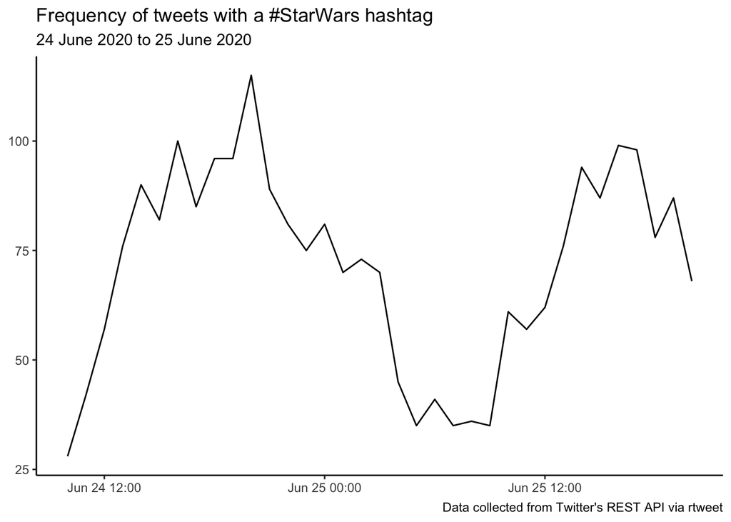

```r
ts_plot(tweets, "hours") +
  labs(x = NULL, y = NULL,
       title = "Frequency of tweets with a #StarWars hashtag",
       subtitle = paste0(format(min(tweets$created_at), "%d %B %Y"), " to ", format(max(tweets$created_at),"%d %B %Y")),
       caption = "Data collected from Twitter's REST API via rtweet") +
  ggplot2::theme_classic()
```

What was the top tweeting **location**

```r
tweets %>%
  filter(!is.na(place_full_name)) %>%
  count(place_full_name, sort = TRUE) %>%
  top_n(5)
```

```
## # A tibble: 5 x 2
##   place_full_name        n
##   <chr>              <int>
## 1 Maryland, USA          6
## 2 San Francisco, CA      5
## 3 Salford, England       4
## 4 Louisville, KY         3
## 5 Zutphen, Nederland     3
```

The most **retweeted** tweet

```r
tweets %>%
  arrange(-retweet_count) %>%
  slice(1) %>%
  select(created_at, screen_name, text, retweet_count)
```

```
## # A tibble: 1 x 4
##   created_at          screen_name   text                           retweet_count
##   <dttm>              <chr>         <chr>                                  <dbl>
## 1 2020-06-24 16:09:54 RamenDoodles… *Aggressive cuddling*! Saw tw…          1098
```

The most **liked** tweet

```r
tweets %>%
  arrange(-favorite_count) %>%
  top_n(5, favorite_count) %>%
  select(created_at, screen_name, text, favorite_count)
```

```
## # A tibble: 5 x 4
##   created_at          screen_name   text                          favorite_count
##   <dttm>              <chr>         <chr>                                  <dbl>
## 1 2020-06-24 15:56:31 thisuserisan… "Gender swap AU (just obi-wa…           6753
## 2 2020-06-24 16:09:54 RamenDoodles… "*Aggressive cuddling*! Saw …           3944
## 3 2020-06-24 19:22:41 starwars      "It’s The #StarWarsShow! Thi…           1623
## 4 2020-06-24 21:10:21 TheSWU        "‘The Rise Of Skywalker’ art…           1170
## 5 2020-06-25 13:22:43 PhilSzostak   "“A little after hours proje…            983
```

Who were the **top** tweeters

```r
tweets %>%
  count(screen_name, sort = TRUE) %>%
  top_n(10) %>%
  mutate(screen_name = paste0("@", screen_name))
```

```
## # A tibble: 10 x 2
##    screen_name          n
##    <chr>            <int>
##  1 @bpdstarwars       124
##  2 @FanthaTracks       30
##  3 @StarWarsRP         27
##  4 @tpnalliance        27
##  5 @rcmadiax           24
##  6 @ST4RW4RS           22
##  7 @JediNewsNetwork    21
##  8 @AnakinS03737461    17
##  9 @VintageStarWars    16
## 10 @ClassicStarWars    10
```

What was the most used **emoji**

```r
# install.packages("devtools")
devtools::install_github("hadley/emo")

library(emo)
tweets %>%
  mutate(emoji = ji_extract_all(text)) %>%
  unnest(cols = c(emoji)) %>%
  count(emoji, sort = TRUE) %>%
  top_n(10)
```

```
## # A tibble: 10 x 2
##    emoji     n
##    <chr> <int>
##  1 🔗      128
##  2 😍       35
##  3 😂       30
##  4 🤣       29
##  5 👉       28
##  6 ❤️       20
##  7 🚨       16
##  8 😎       15
##  9 👍       14
## 10 😁       14
```

What were the top 10 **hashtags**

```r
tweets %>%
  unnest_tokens(hashtag, text, "tweets", to_lower = FALSE) %>%
  filter(str_detect(hashtag, "^#"),
         hashtag != "#StarWars") %>%
  count(hashtag, sort = TRUE) %>%
  top_n(10)
```

```
## # A tibble: 12 x 2
##    hashtag             n
##    <chr>           <int>
##  1 #starwars         809
##  2 #eBay             135
##  3 #TheMandalorian    86
##  4 #Disney            47
##  5 #marvel            45
##  6 #STARWARS          45
##  7 #Starwars          43
##  8 #topps             41
##  9 #babyyoda          40
## 10 #darthvader        39
## 11 #disney            39
## 12 #LEGO              39
```

Top **mentions**

```r
tweets %>%
  unnest_tokens(mentions, text, "tweets", to_lower = FALSE) %>%
  filter(str_detect(mentions, "^@")) %>%
  count(mentions, sort = TRUE) %>%
  top_n(10)
```

```
## # A tibble: 11 x 2
##    mentions            n
##    <chr>           <int>
##  1 @starwars          51
##  2 @YouTube           26
##  3 @HamillHimself     23
##  4 @Disney            20
##  5 @Poshmarkapp       14
##  6 @EAStarWars        11
##  7 @StarWars          11
##  8 @eBay              10
##  9 @Hasbro             9
## 10 @LEGOGroup          9
## 11 @themandalorian     9
```

### Add a touch of text analysis

Let’s examine the most frequently used words in these tweets

```r
words <- tweets %>%
  mutate(text = str_remove_all(text, "&amp;|&lt;|&gt;"),
         text = str_remove_all(text, "\\s?(f|ht)(tp)(s?)(://)([^\\.]*)[\\.|/](\\S*)"),
         text = str_remove_all(text, "[^\x01-\x7F]")) %>%
  unnest_tokens(word, text, token = "tweets") %>%
  filter(!word %in% stop_words$word,
         !word %in% str_remove_all(stop_words$word, "'"),
         str_detect(word, "[a-z]"),
         !str_detect(word, "^#"),
         !str_detect(word, "@\\S+")) %>%
  count(word, sort = TRUE)
```

Finally - let’s use the wordcloud package to create a visualisation of the word frequencies.

[figure not shown]

```r
library(wordcloud)
words %>%
  with(wordcloud(word, n, random.order = FALSE, max.words = 100, colors = "#F29545"))
```